# ECE 5470 Lab 3 Report

## by Junjie Tian

```python
import numpy as np
from v4 import vx
from v4 import vd

vd.dispmvx("mp.vx", size=0.3, capt="im1.vx")
```

[output not shown]

```
im1.vx
<scaled size: (512 x 512) >
```

### Section 2

#### Step 1-3 for 'mp.vx'

The following are results of 'mp.vx'. The grayscale values of the original graph are mostly between 70 and 230, with two peaks of around 80 and 170. The threshold value is around 150. In the output graph, the general shape of the motor shaft is shown, but the contour of the circles is not complete. Besides, some details such as the two small holes on the upper part are missing. Generally, we can see the shape of the object, but some details are missing as only one threshold value is used.

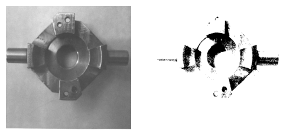

```
result of vtpeakpy on mp.vx with d=10
<scaled size: (512 x 512) (512 x 512) >
```

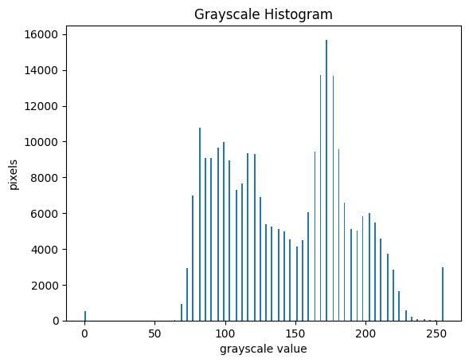

```
Histogram of mp.vx
```

```python
exec(vx.vxsh('vtpeakpy mp.vx of=mpt.vx'))
vd.dispmvx('mp.vx','mpt.vx',size=0.75,  capt='result of vtpeakpy on mp.vx with d=10')
vd.dhist('mp.vx', capt='Histogram of mp.vx')
```

#### Step 1-3 for 'nb.vx'

The following are results of 'nb.vx'. The grayscale values of the original graph are mostly between 50 and 220, with two peaks of around 140 and 200). The threshold value is around 190. In the output graph, the shapes of the long rod in the upper part and the hollow hexagon are shown, but the shape of the other two objects are not clearly presented. One of the reasons is that the grayscale values of the blurry shadow are around the threshold value and the area of shadow are large; thus, some of the shadow area is shown as black in the output and connecting some main objects together. The other reason is that the middle part of the hexagon on the right has shadow with large pixel values, so the whole hexagon is in black in the output image. In summary, the transformed graph of 'nb.vx' doesn't represent the original graph clearly.

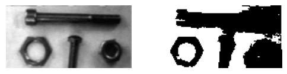

```
result of vtpeakpy on nb.vx with d=10
<scaled size: (64 x 128) (64 x 128) >
```

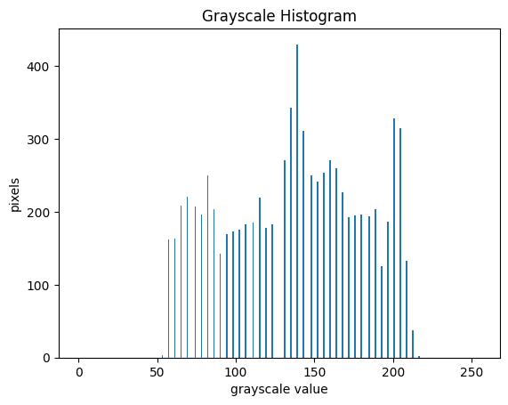

```
Histogram of nb.vx
```

```python
exec(vx.vxsh('vtpeakpy nb.vx of=nbt.vx'))
vd.dispmvx('nb.vx','nbt.vx',size=0.75,  capt='result of vtpeakpy on nb.vx with d=10')
vd.dhist('nb.vx', capt='Histogram of nb.vx')
```

#### Step 1-3 for 'map'

The following are results of 'map'. The grayscale values of the original graph are mostly between 20 and 250. The total number of pixels of the graph is way higher than the previous two pictures, so the distribution in the histogram is continuous. The two peaks are around 115 and 130. The threshold value is around 125. In the output graph, there is a circular shape, within which contains most information of the map. However, there is a portion with black pixels only in the output graph, and the map information in that region is lost. For the white portion of the output, the information is shown clearly, and the contrasting effect of the shadow in the original graph doesn't appear. The reason is that there is only a single threshold so the gray pixels in the original graph are transformed to white in the output. There are some black dots in the river, which is different from the original gray pixels. Overall, large portion of the map is clearer than before while some information is totally lost.

[figure not shown]

```
result of vtpeakpy on map with d=10
<scaled size: (512 x 512) (512 x 512) >
```

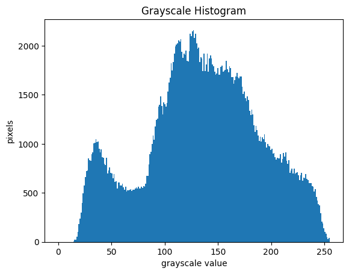

```
Histogram of map
```

```python
exec(vx.vxsh('vtpeakpy map of=mapt.vx'))
vd.dispmvx('map','mapt.vx',size=0.75,  capt='result of vtpeakpy on map with d=10')
vd.dhist('map', capt='Histogram of map')
```

#### Step 1-3 for 'facsimile'

The following are results of 'facsimile'. In the histogram, there is a very high peak at around grayscale value of 240. There are also some pixel values between 80 and 200, but the height of the bars is way lower. The two peaks are around 0 and 240. The threshold value maybe very close to 0. By analyzing the code, we know that 'minbin' is assigned to a very small value (where no pixel is at that value); although there are some values with 0 pixel, it cannot be even smaller than 0, so 'minbin' will be very small. In the output graph, most of the region is in black. The reason is analyzed in the above paragraph; as the 'nxtbin' should be more than 10 pixels away from the highest peak, the 'nxtbin' is assigned to be 0. Thus, the threshold value is very low, and most region is in black in the output graph.

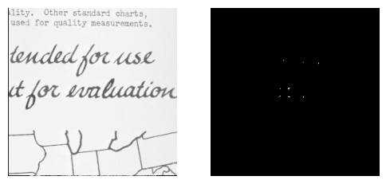

```
result of vtpeakpy on facsimile with d=10
<scaled size: (256 x 256) (256 x 256) >
```

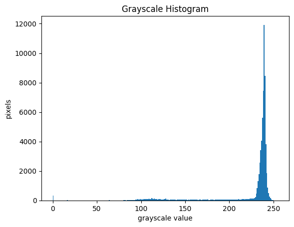

```
Histogram of facsimile
```

```python
exec(vx.vxsh('vtpeakpy facsimile of=facsimilet.vx'))
vd.dispmvx('facsimile','facsimilet.vx',size=0.75,  capt='result of vtpeakpy on facsimile with d=10')
vd.dhist('facsimile', capt='Histogram of facsimile')
```

#### Step 1-3 for 'shtl.vx'

[figure not shown]

```
result of vtpeakpy on shtl.vx with d=10
<scaled size: (256 x 256) (256 x 256) >
```

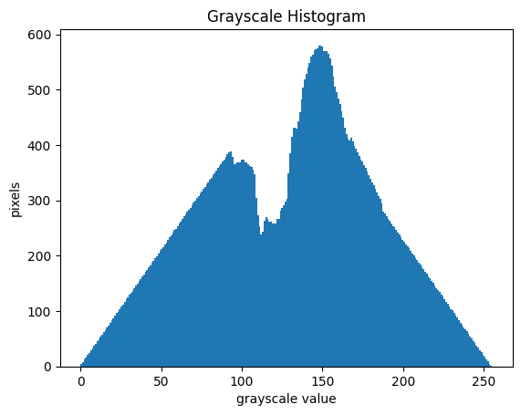

```
Histogram of shtl.vx
```

```python
exec(vx.vxsh('vtpeakpy shtl.vx of=shtlt.vx'))
vd.dispmvx('shtl.vx','shtlt.vx',size=0.75,  capt='result of vtpeakpy on shtl.vx with d=10')
vd.dhist('shtl.vx', capt='Histogram of shtl.vx')
```

#### Step 4

Discussion: I choose to make d less than 10 instead of greater than 10. By doing so, the second highest peak detected in the algorithm will be closer to the highest peak, and the threshold is around the highest peak. Thus, the noise on the top-right corner will not be connected together with the main object. People can have a clearer sense of how the object on the upper part looks like, as they can recognize that the top-right corner contains noise. Besides, the upper part object is separated from the object in the middle of the lower part by some white space.

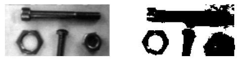

[output not shown]

```python
exec(vx.vxsh('vtpeakpy nb.vx of=nb_step4.vx d=2'))
vd.dispmvx('nb.vx','nb_step4.vx',size=0.75,  capt='result of vtpeakpy on nb.vx with d=10')
```

### Section 3 Iterative Threshold Selection (vits)

#### 3.2 Program Discussion

In this program, I first write functions to classify all pixels into two parts and calculate the average pixel values of each part. Then I apply these functions iteratively to update the threshold values. If the average values are same (absolute difference below epsilon value), we stop the while loop; if we have finished 100 iterations, the while loop is also stopped. Then we apply the threshold on the input picture.

#### 3.3 Small image tests

```python
# Code to convert from .csv to .vx
import pandas as pd
def vxread_csv( ifile, whitespace=False):
    ''' read a csv file or file with whitespace separators
        and return vx ubyte image file
        only 2D images supported
    '''
    if whitespace:
        df = pd.read_csv(ifile, header=None, sep='\s+')
    else:
        df = pd.read_csv(ifile, header=None, )
    return vx.Vx(df.to_numpy(dtype='uint8', copy=True))
```

```
Input Test Image
<scaled size: (10 x 17) >
```

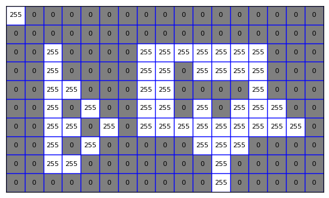

```
Output Test Image
<scaled size: (10 x 17) >
```

```python
# Read in the test image
q4_small_test_in_1 = vxread_csv('q4_test_1.csv')
vd.dispmvx(q4_small_test_in_1, pvalues=True, capt="Input Test Image")

# Execute Command
exec(vx.vxsh( 'chmod +x vits '))
q4_small_test_out_1 = vx.Vx()
exec(vx.vxsh( 'vrawtovx -t q4_test_1.csv | vdim -c of=$q4_small_test_in_1' ))
exec(vx.vxsh( 'vits if=$q4_small_test_in_1 of=$q4_small_test_out_1'))
vd.dispmvx(q4_small_test_out_1, pvalues=True, capt="Output Test Image")
```

Discussion: As the number of zero pixels is very high, after some iterations in the algorithm, the threshold value will be a number between 0 and 1. Thus, it is expected that in the output picture, all pixels with non-zero grayscale values will be 255, while others are 0.

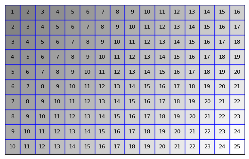

```
Input Test Image
<scaled size: (10 x 16) >
```

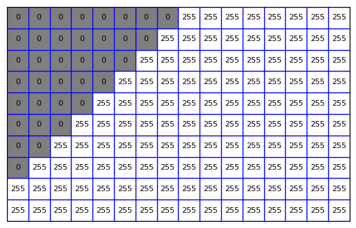

```
Output Test Image
<scaled size: (10 x 16) >
```

```python
# Read in the test image
q4_small_test_in_2 = vxread_csv('q4_test_2.csv')
vd.dispmvx(q4_small_test_in_2, pvalues=True, capt="Input Test Image")

# Execute Command
q4_small_test_out_2 = vx.Vx()
exec(vx.vxsh( 'vrawtovx -t q4_test_2.csv | vdim -c of=$q4_small_test_in_2' ))
exec(vx.vxsh( 'vits if=$q4_small_test_in_2 of=$q4_small_test_out_2'))
vd.dispmvx(q4_small_test_out_2, pvalues=True, capt="Output Test Image")
```

Discussion: This small test image simulates a situation of grayscale values increase in a diagonal direction. The average value is between 8 and 9, so it is expected that in the output image, the top-left region will be in black while other parts are in white. The program works as expected.

#### 3.4 Large Imge tests

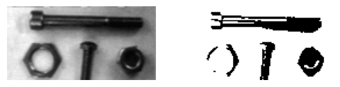

```
result of vits on nb.vx
<scaled size: (64 x 128) (64 x 128) >
```

```python
exec(vx.vxsh('vits if=nb.vx of=nb_vits.vx'))
vd.dispmvx('nb.vx','nb_vits.vx',size=0.75,  capt='result of vits on nb.vx')
```

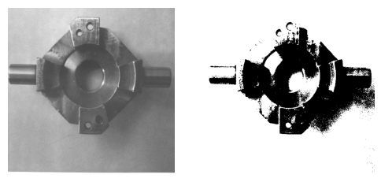

```
result of vits on mp.vx
<scaled size: (512 x 512) (512 x 512) >
```

```python
exec(vx.vxsh('vits if=mp.vx of=mp_vits.vx'))
vd.dispmvx('mp.vx','mp_vits.vx',size=0.75,  capt='result of vits on mp.vx')
```

Discussion: In the output picture, the contour of the object is shown clearer than in 'vtpeakpy'. Larger portion of the main object is shown in black instead of white compared to the result of 'vtpeakpy'. Three out of four small holes are shown in the output picture, and the one not shown is very dark in the original picture. There is a black region that is not part of the object in the output image, because that part in the original image is darker than other shadowing part. Generally, 'vits' is better than 'vtpeakpy'.

### 4.Region Growing (vgrow)

#### 4.2 Program Discussion

In the above program, I used the main structure of the cclabel file. I changed the input parameters to include 'r=' and '-p'. In the setlabel helper function, I added the logic to check whether pixels are within range. Then I write two labeling methods based on different 'optp'.

#### 4.3 Small image tests

```
Input Test Image
<scaled size: (10 x 17) >
```

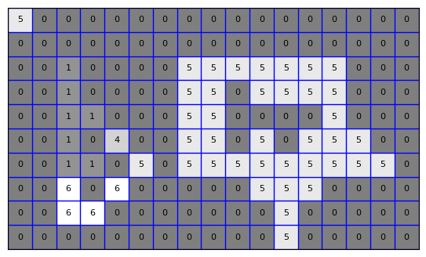

```
Output Test Image
<scaled size: (10 x 17) >
```

```python
exec(vx.vxsh( 'chmod +x vgrow '))
q5_small_test_in = vxread_csv('q4_test_1.csv')
vd.dispmvx(q5_small_test_in, pvalues=True, capt="Input Test Image")

# Execute Command
q5_small_test_out = vx.Vx()
exec(vx.vxsh( 'vrawtovx -t q4_test_1.csv | vdim -c of=$q5_small_test_in' ))
exec(vx.vxsh( 'vgrow if=$q5_small_test_in of=$q5_small_test_out r=4 -p'))

vd.dispmvx(q5_small_test_out, pvalues=True, capt="Output Test Image")
```

Discussion: In the above small test image, I tried the following scenarios: a single pixel in the corner, pixels that are 8-connected but not 4-connected, same region in cclabel but different region when range=4. As I included the '-p' parameter, the pixel values of a region will be the pixel value of the first pixel. The program works well in this small test image, as pixel values of 6 and 7 are not assigned 1 due to the range constraint. The large portion has pixel value of 5 for all pixels, which is correct.

```
Input Test Image
<scaled size: (10 x 17) >
```

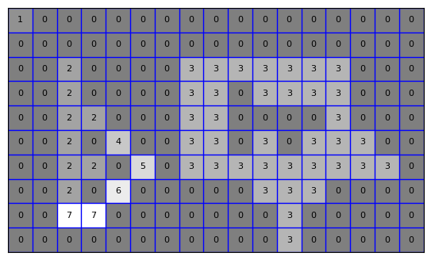

```
Output Test Image
<scaled size: (10 x 17) >
```

```python
q5_small_test_in = vxread_csv('q4_test_1.csv')
vd.dispmvx(q5_small_test_in, pvalues=True, capt="Input Test Image")

# Execute Command
q5_small_test_out = vx.Vx()
exec(vx.vxsh( 'vrawtovx -t q4_test_1.csv | vdim -c of=$q5_small_test_in' ))
exec(vx.vxsh( 'vgrow if=$q5_small_test_in of=$q5_small_test_out r=4'))

vd.dispmvx(q5_small_test_out, pvalues=True, capt="Output Test Image")
```

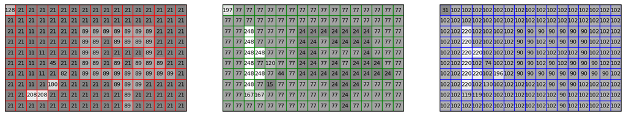

```
Output Test Image
<scaled size: (10 x 17) (10 x 17) (10 x 17) >
```

```python
# Try to use 'false' coloring on the previous output
q5_small_test_out = vx.Vx()
exec(vx.vxsh( 'vrawtovx -t q4_test_1.csv | vdim -c of=$q5_small_test_in' ))
exec(vx.vxsh( 'vgrow if=$q5_small_test_in of=$q5_small_test_out r=4'))

exec(vx.vxsh( 'vcmap if=$q5_small_test_out of=colored_form.vx lf=rand'))
vd.dispmvx('colored_form.vx', size=2, pvalues=True, capt="Output Test Image")
```

Discussion: In this case, I deleted the '-p' statement, so the regions will be ordered sequentially. This is what we expected. For other regions, the connected pixels are all labeled the same number.

#### 4.4 Large Imge tests

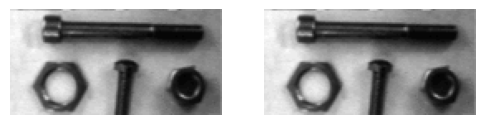

```
result of vgrow on nb.vx
<scaled size: (64 x 128) (64 x 128) >
```

```python
q5_test_out = vx.Vx()
exec(vx.vxsh( 'vgrow if=nb.vx of=$q5_test_out r=3 -p'))
vd.dispmvx('nb.vx', q5_test_out,size=0.75,  capt='result of vgrow on nb.vx')
```

When the range value is r=3, the segmentation is the best.

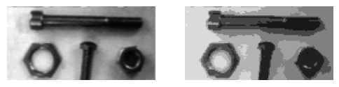

```
result of vgrow on nb.vx
<scaled size: (64 x 128) (64 x 128) >
```

```python
q5_test_out = vx.Vx()
exec(vx.vxsh( 'vgrow if=nb.vx of=$q5_test_out r=20 -p'))
vd.dispmvx('nb.vx', q5_test_out,size=0.75,  capt='result of vgrow on nb.vx')
```

Discussion: Now I intentionally make the range value larger and r=20. The output is more blurry than before, as larger regions are assigned the same pixel value. The shadowing part is connected into bigger region with same grayscale value, so the difference in the pixel values of the background is way smaller. This is not the optimal range value, but it is used here to test the algorithm.

[figure not shown]

```
result of vgrow on shtl.vx
<scaled size: (256 x 256) (256 x 256) >
```

```python
q5_test_out = vx.Vx()
exec(vx.vxsh( 'vgrow if=shtl.vx of=$q5_test_out r=1'))
vd.dispmvx('shtl.vx', q5_test_out,size=0.75,  capt='result of vgrow on shtl.vx')
```

Discussion: In the above output picture, I made the range value very tight. The output has a larger dark area on the top-left part and smaller white area on the bottom-right part. As the contrasting effect is stronger, the object is a bit clearer than the original picture.

[figure not shown]

```
result of vgrow on shtl.vx
<scaled size: (256 x 256) (256 x 256) >
```

```python
q5_test_out = vx.Vx()
exec(vx.vxsh( 'vgrow if=shtl.vx of=$q5_test_out r=2'))
vd.dispmvx('shtl.vx', q5_test_out,size=0.75,  capt='result of vgrow on shtl.vx')
```

Discussion: The range value is increased from 1 to 2. As the contrasting effect in the background is stronger, the main object is shown clearer than before.

When the range value is 2, the segmentation is the best.

#### 4.5 Edge Image tests

[figure not shown]

```
result of vsobel on shtl.vx
<scaled size: (256 x 256) (256 x 256) >
```

```python
exec(vx.vxsh('vsobel shtl.vx of=edge.vx'))
vd.dispmvx('shtl.vx', 'edge.vx',size=0.75,  capt='result of vsobel on shtl.vx')
```

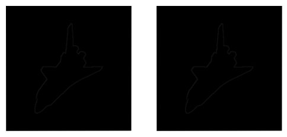

```
result of vgrow on edge.vx
<scaled size: (256 x 256) (256 x 256) >
```

[figure not shown]

```
result of vpix on edge_out.vx
<scaled size: (256 x 256) (256 x 256) >
```

```python
exec(vx.vxsh( 'vgrow if=edge.vx of=edge_out.vx r=10'))
vd.dispmvx('edge.vx', 'edge_out.vx',size=0.75,  capt='result of vgrow on edge.vx')

exec(vx.vxsh('vpix if=edge_out.vx of=edge_out_print.vx th=2'))
vd.dispmvx('edge_out.vx', 'edge_out_print.vx',size=0.75,  capt='result of vpix on edge_out.vx')
```

Discussion: I firstly used the vsobel function to produce an edge detected image, then applied vgrow, and finally used vpix to show the output picture clearly. There's no parameter in the vsobel function. In the output of vsobel function, if we zoom in in the simba viewer, we can see a clear edge of the main object. The parameter r can be of any value as long as the edge is not 'merged' as the same pixel value as the background dark. The acceptable range for the parameter r is very large. Finally, we set the parameter threshold to be 2 in the vpix function; thus, all grayscale values less than 2 are simply 0 and others are 255 in the output. The edge is clearly shown in the output image.